# Breast Cancer Cell Lines Atlas — Single-Cell RNA-seq

```r
set.seed(7)
options(stringsAsFactors = FALSE)

RUN_MARKERS <- FALSE

suppressPackageStartupMessages({
  library(Seurat)
  library(Matrix)
  library(dplyr)
  library(ggplot2)
  library(patchwork)
  library(tidyr)
  library(stringr)
  library(biomaRt)
  library(viridis)
})

root_dir <- normalizePath(file.path(".."))
mtx_dir <- file.path(root_dir, "data", "MTX_FMT_GSE173634")
mtx_file <- file.path(mtx_dir, "matrix.mtx")
features_file <- file.path(mtx_dir, "features.tsv")
barcodes_file <- file.path(mtx_dir, "barcodes.tsv")

if (!file.exists(mtx_file)) {
  stop("Missing MTX files. Download the Kaggle dataset into breast-cancer-scrna/data.")
}
```

# Why this dataset

This is a single-cell atlas of 32 human breast cancer cell lines (35,276 cells) originally published as GSE173634. I picked it because it’s a clean, well-annotated dataset with a wide range of molecular subtypes. That makes it a good playground for testing clustering quality, state scoring, and marker-driven interpretation.

# Load counts

We start from the Matrix Market files bundled with the dataset. Barcodes embed the cell-line label, so we recover it directly from the IDs.

```r
bc_counts <- ReadMtx(mtx = mtx_file, features = features_file, cells = barcodes_file, feature.column = 1)

bc <- CreateSeuratObject(counts = bc_counts, min.cells = 3, min.features = 200)
bc$cell_line <- sub("_.*", "", colnames(bc))

bc
```

```
## An object of class Seurat
## 40726 features across 35276 samples within 1 assay
## Active assay: RNA (40726 features, 0 variable features)
##  1 layer present: counts
```

```r
head(bc@meta.data)
```

```
##                    orig.ident nCount_RNA nFeature_RNA cell_line
## AU565_AAACCAGTTTGG      AU565       7399         2543     AU565
## AU565_AAACGTGCAGCG      AU565       8920         2970     AU565
## AU565_AAAGCCACATGC      AU565       6571         2453     AU565
## AU565_AAAGTCGGCTGG      AU565       6567         2384     AU565
## AU565_AAAGTGCCTAAA      AU565       8123         2894     AU565
## AU565_AAATCATCTTAT      AU565       5818         2358     AU565
```

# QC and filtering

I keep the QC story simple: remove empty droplets and clear low-quality cells. I’m not doing aggressive filtering because these are cell lines, but I still want to avoid obvious junk.

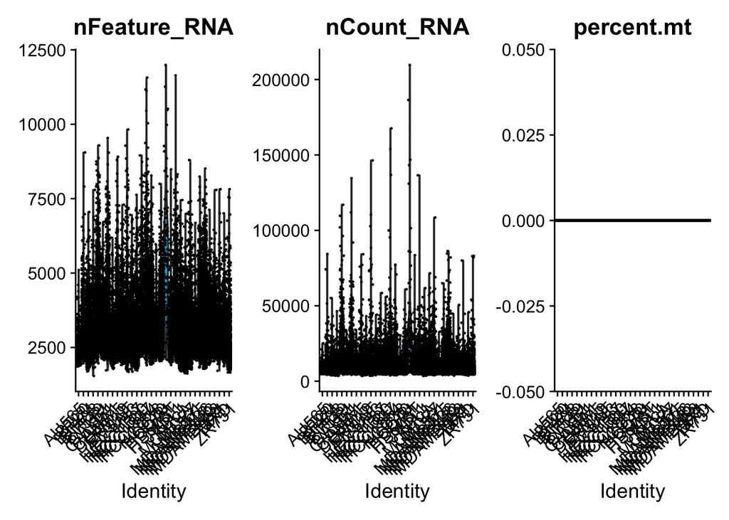

```r
bc[["percent.mt"]] <- PercentageFeatureSet(bc, pattern = "^MT-")

VlnPlot(bc, features = c("nFeature_RNA", "nCount_RNA", "percent.mt"), ncol = 3)
```

```r
bc <- subset(bc, subset = nFeature_RNA > 300 & nFeature_RNA < 7000 & percent.mt < 20)

bc
```

```
## An object of class Seurat
## 40726 features across 35032 samples within 1 assay
## Active assay: RNA (40726 features, 0 variable features)
##  1 layer present: counts
```

# Normalize + feature selection

I use log-normalization and select highly variable genes. It’s fast and gives clean separation for this scale of data.

```r
bc <- NormalizeData(bc)
```

```
## Normalizing layer: counts
```

```r
bc <- FindVariableFeatures(bc, selection.method = "vst", nfeatures = 3000)
```

```
## Finding variable features for layer counts
```

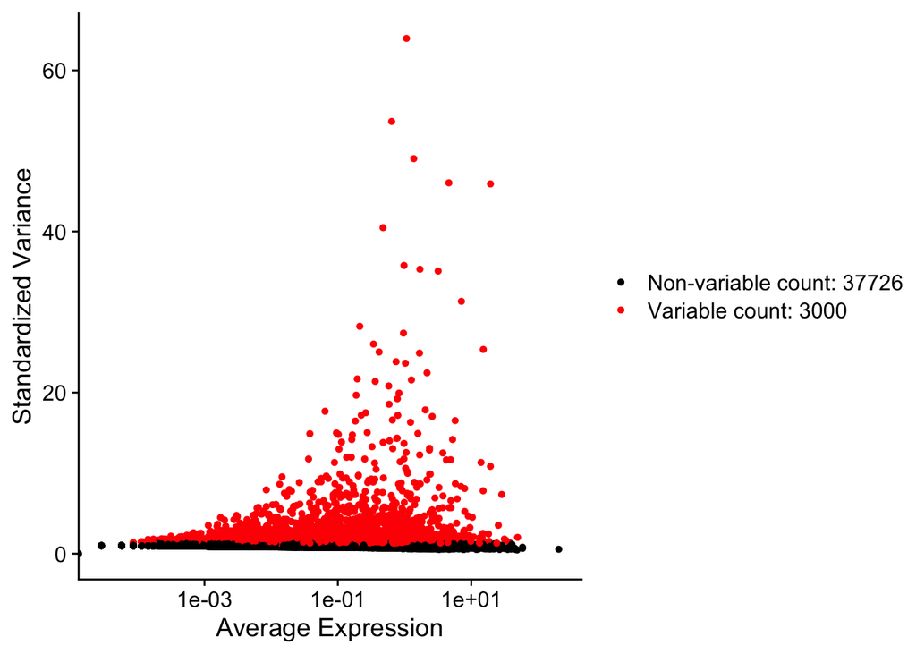

```r
VariableFeaturePlot(bc)
```

# Dimensionality reduction and clustering

PCA → UMAP → clustering. I keep the resolution moderate to avoid splitting cell lines into tiny micro-clusters unless the data strongly supports it.

```r
bc <- ScaleData(bc, features = VariableFeatures(bc))
bc <- RunPCA(bc, features = VariableFeatures(bc))
```

[output not shown]

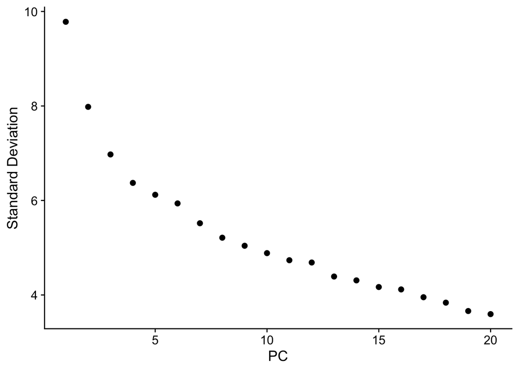

```r
ElbowPlot(bc)
```

```r
bc <- FindNeighbors(bc, dims = 1:30)
bc <- FindClusters(bc, resolution = 0.4)
```

```
## Modularity Optimizer version 1.3.0 by Ludo Waltman and Nees Jan van Eck
##
## Number of nodes: 35032
## Number of edges: 1474104
##
## Running Louvain algorithm...
## Maximum modularity in 10 random starts: 0.9838
## Number of communities: 34
## Elapsed time: 5 seconds
```

```r
bc <- RunUMAP(bc, dims = 1:30)
```

```
## 21:20:28 Found 13 connected components, falling back to 'spca' initialization with init_sdev = 1
## 21:20:28 PCA: 2 components explained 22.99% variance
## 21:20:28 Scaling init to sdev = 1
```

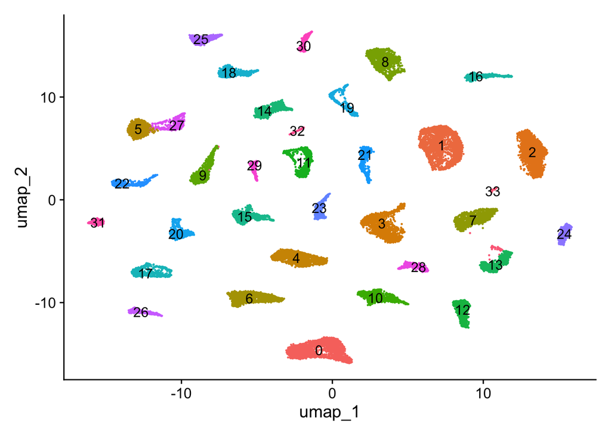

```r
DimPlot(bc, reduction = "umap", label = TRUE) + NoLegend()
```

# Cell line context

The barcode prefix encodes cell-line identity, so I keep it as a grouping label.

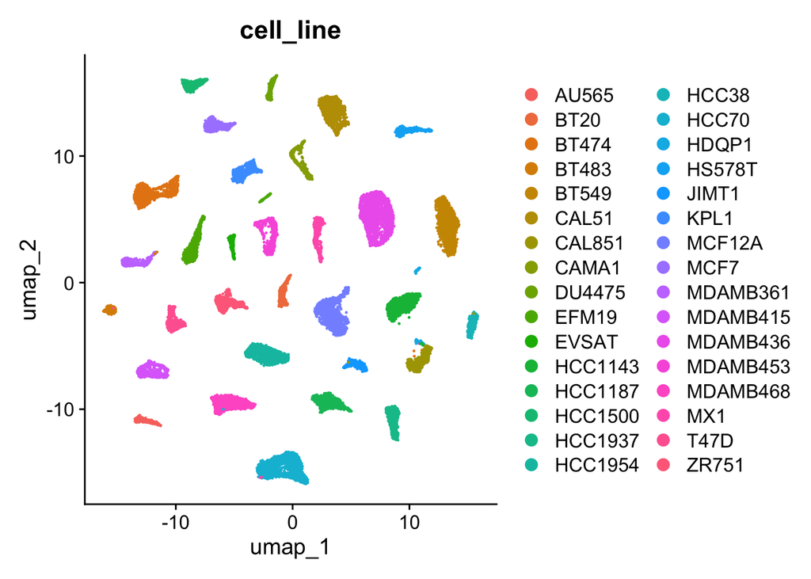

```r
DimPlot(bc, reduction = "umap", group.by = "cell_line", label = FALSE) +
  guides(color = guide_legend(override.aes = list(size = 3), ncol = 2))
```

# Cell-cycle scoring

This adds some biological context that’s often hidden in raw clusters.

```r
mart <- NULL
for (mirror in c("useast", "uswest", "asia", "www")) {
  mart <- tryCatch(
    biomaRt::useEnsembl(biomart = "genes", dataset = "hsapiens_gene_ensembl", mirror = mirror),
    error = function(e) NULL
  )
  if (!is.null(mart)) break
}

if (is.null(mart)) {
  stop("Unable to connect to Ensembl via biomaRt. Try again later or set a different mirror.")
}

map_symbols <- function(symbols) {
  symbol_map <- biomaRt::getBM(
    attributes = c("hgnc_symbol", "ensembl_gene_id"),
    filters = "hgnc_symbol",
    values = unique(symbols),
    mart = mart
  )

  symbol_map <- symbol_map %>%
    dplyr::filter(hgnc_symbol != "", ensembl_gene_id %in% rownames(bc)) %>%
    dplyr::distinct(hgnc_symbol, .keep_all = TRUE)

  setNames(symbol_map$ensembl_gene_id, symbol_map$hgnc_symbol)
}
```

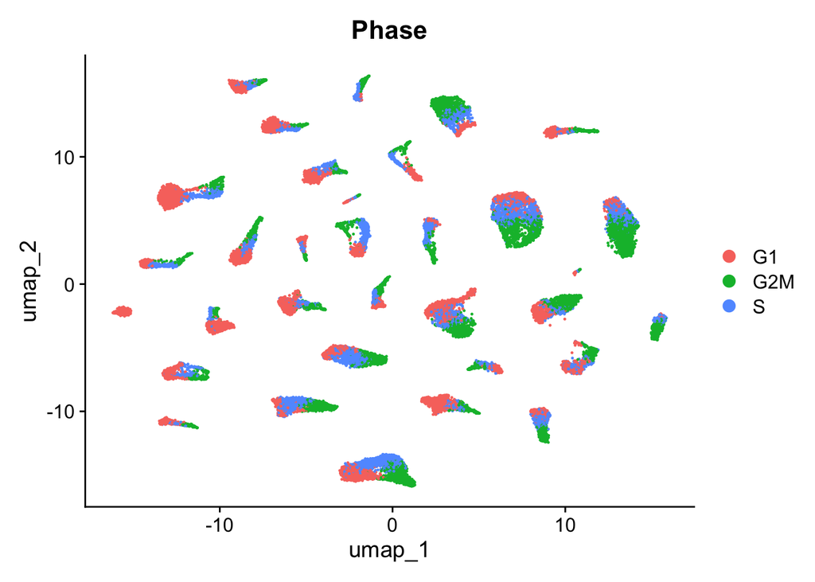

```r
cc <- Seurat::cc.genes

s_genes <- unname(map_symbols(cc$s.genes))
g2m_genes <- unname(map_symbols(cc$g2m.genes))

if (length(s_genes) >= 10 && length(g2m_genes) >= 10) {
  bc <- CellCycleScoring(bc, s.features = s_genes, g2m.features = g2m_genes)
  DimPlot(bc, reduction = "umap", group.by = "Phase")
} else {
  message("Cell-cycle scoring skipped: not enough cell-cycle genes matched.")
}
```

# Gene symbol mapping

The count matrix uses Ensembl IDs. For the state scores and plots below, I map a small set of gene symbols to their Ensembl IDs.

```r
symbol_sets <- list(
  Epithelial = c("EPCAM", "KRT8", "KRT18", "KRT19", "MUC1"),
  Mesenchymal = c("VIM", "FN1", "ZEB1", "ZEB2", "COL1A1"),
  Proliferative = c("MKI67", "TOP2A", "HMGB2", "TYMS", "STMN1"),
  Stress = c("FOS", "JUN", "HSPA1A", "HSP90AA1"),
  PlotGenes = c("EPCAM", "KRT19", "VIM", "MKI67", "TOP2A", "ERBB2", "ESR1")
)

target_symbols <- unique(unlist(symbol_sets))

symbol_to_ens <- map_symbols(target_symbols)
```

# State scoring (epithelial vs mesenchymal)

These scores are not “cell types” in the classical sense, but they help interpret how clusters lean along common cancer state axes.

[figure not shown]

```r
state_sets <- lapply(symbol_sets[names(symbol_sets) != "PlotGenes"], function(g) unname(symbol_to_ens[g]))
state_sets <- lapply(state_sets, function(g) g[!is.na(g)])
state_sets <- state_sets[lengths(state_sets) > 0]

if (length(state_sets) == 0) {
  stop("No state gene sets matched the dataset.")
}

bc <- AddModuleScore(bc, features = state_sets, name = names(state_sets))

score_cols <- paste0(names(state_sets), "1")
score_cols <- score_cols[score_cols %in% colnames(bc@meta.data)]

if (length(score_cols) > 0) {
  FeaturePlot(bc, features = score_cols, ncol = 2)
} else {
  message("State scores skipped: no score columns were created.")
}
```

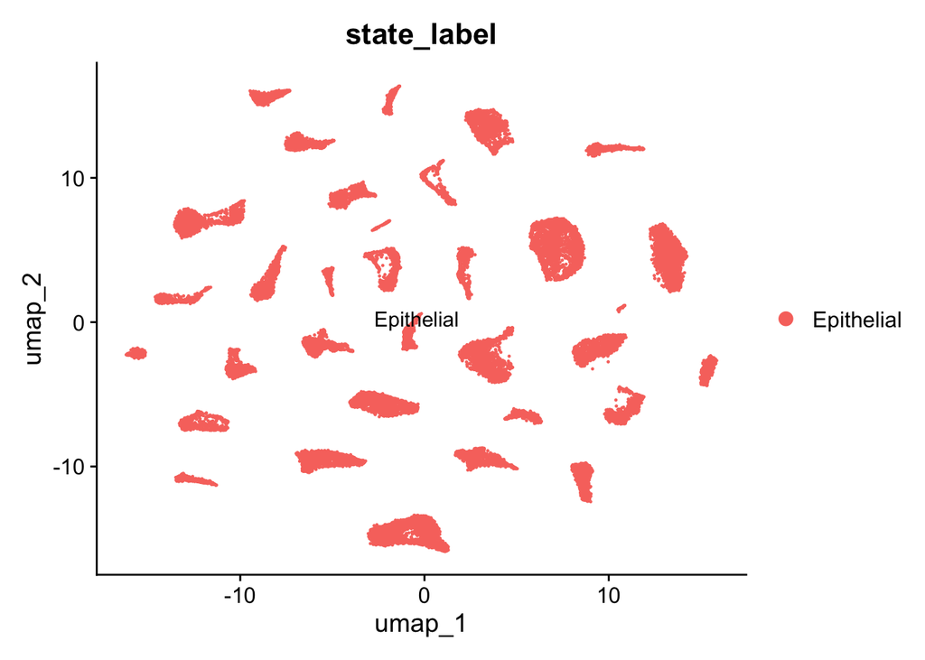

```r
if (length(score_cols) > 0) {
  score_df <- bc@meta.data %>%
    dplyr::select(seurat_clusters, all_of(score_cols)) %>%
    dplyr::group_by(seurat_clusters) %>%
    dplyr::summarize(across(all_of(score_cols), mean), .groups = "drop")

  score_mat <- as.data.frame(score_df)
  row.names(score_mat) <- score_mat$seurat_clusters
  score_mat$seurat_clusters <- NULL

  state_labels <- apply(score_mat, 1, function(x) names(state_sets)[which.max(x)])

  bc$state_label <- unname(state_labels[as.character(bc$seurat_clusters)])

  DimPlot(bc, reduction = "umap", group.by = "state_label", label = TRUE)
} else {
  message("State labels skipped: no scores available.")
}
```

# Marker discovery

Markers help explain *why* a cluster exists. This step is optional because it can be slow on laptops. Toggle `RUN_MARKERS` in the setup chunk if you want to run it.

```r
if (RUN_MARKERS) {
  bc_markers <- subset(bc, downsample = 20)

  markers <- FindAllMarkers(
    bc_markers,
    only.pos = TRUE,
    min.pct = 0.15,
    logfc.threshold = 0.3
  )

  top_markers <- markers %>%
    group_by(cluster) %>%
    slice_max(avg_log2FC, n = 5) %>%
    ungroup()

  marker_map <- biomaRt::getBM(
    attributes = c("ensembl_gene_id", "hgnc_symbol"),
    filters = "ensembl_gene_id",
    values = unique(top_markers$gene),
    mart = mart
  )

  top_markers %>%
    dplyr::left_join(marker_map, by = c("gene" = "ensembl_gene_id")) %>%
    dplyr::mutate(gene_label = ifelse(hgnc_symbol != "", hgnc_symbol, gene)) %>%
    dplyr::select(cluster, gene_label, avg_log2FC, pct.1, pct.2)
} else {
  message("Marker discovery skipped. Set RUN_MARKERS <- TRUE to run it.")
}
```

```
## Marker discovery skipped. Set RUN_MARKERS <- TRUE to run it.
```

# Gene boxplots

**Why these genes:**

- `EPCAM` and `KRT19` flag epithelial programs.
- `VIM` points to mesenchymal-like states.
- `MKI67` and `TOP2A` highlight cycling / proliferative clusters.
- `ERBB2` and `ESR1` map onto HER2/ER signaling that’s central in breast cancer.

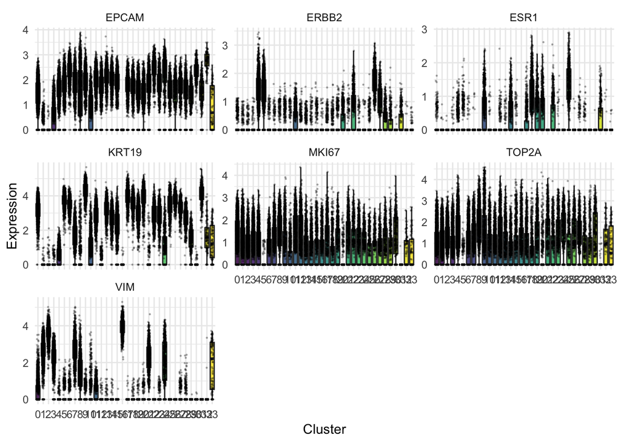

```r
plot_genes_sym <- symbol_sets$PlotGenes
plot_gene_labels <- setNames(plot_genes_sym, symbol_to_ens[plot_genes_sym])
plot_gene_labels <- plot_gene_labels[!is.na(names(plot_gene_labels))]
plot_genes <- names(plot_gene_labels)

expr <- FetchData(bc, vars = c("seurat_clusters", plot_genes))
expr_long <- expr %>%
  pivot_longer(cols = all_of(plot_genes), names_to = "gene", values_to = "expr")

expr_long$seurat_clusters <- factor(expr_long$seurat_clusters)
expr_long$gene <- plot_gene_labels[expr_long$gene]

p <- ggplot(expr_long, aes(x = seurat_clusters, y = expr, fill = seurat_clusters)) +
  geom_boxplot(outlier.shape = NA, alpha = 0.85) +
  geom_jitter(size = 0.2, width = 0.2, alpha = 0.25) +
  facet_wrap(~ gene, scales = "free_y") +
  scale_fill_viridis_d() +
  labs(x = "Cluster", y = "Expression") +
  theme_minimal(base_size = 11) +
  theme(legend.position = "none")

p
```

# What else you can do next

- Integrate with bulk RNA-seq or drug response data to connect expression states to sensitivity.
- Run pathway enrichment on each cluster for cleaner biological narratives.
- Compare these cell-line states to patient tumor single-cell datasets to see what carries over.

# Summary